# Age structure of minority-language populations in Finland

Victor Makara

2026-09-25

# 1 Data

```r
tulos_age <- readRDS("C:/R/tulos_age.rds")
tulos <- readRDS("C:/R/tulos.rds")

age_levels <- c(
  "0 - 4", "5 - 9", "10 - 14", "15 - 19",
  "20 - 24", "25 - 29", "30 - 34", "35 - 39",
  "40 - 44", "45 - 49", "50 - 54", "55 - 59",
  "60 - 64", "65 - 69", "70 - 74", "75 -"
)

tulos_age <- tulos_age %>%
  mutate(
    Language = as.character(Language),
    Age = factor(as.character(Age), levels = age_levels)
  )

tulos <- tulos %>%
  mutate(Language = as.character(Language))
```

## 1.1 Consistency check

The sum of the age groups must equal the total stored in `tulos.rds` for every language and year.

```r
age_check <- tulos_age %>%
  group_by(Language, Year) %>%
  summarise(age_total = sum(`Population 31 Dec`), .groups = "drop") %>%
  left_join(
    tulos %>% select(Language, Year, total = `Population 31 Dec`),
    by = c("Language", "Year")
  ) %>%
  mutate(difference = age_total - total)

stopifnot(all(age_check$difference == 0))

data.frame(
  rows = nrow(tulos_age),
  languages = n_distinct(tulos_age$Language),
  first_year = min(tulos_age$Year),
  last_year = max(tulos_age$Year),
  maximum_difference = max(abs(age_check$difference))
)
```

```
##    rows languages first_year last_year maximum_difference
## 1 92736       161       1990      2025                  0
```

# 2 Russian-speaking population

## 2.1 Annual population change

```r
russian_annual <- tulos %>%
  filter(Language == "Russian") %>%
  arrange(Year) %>%
  mutate(Change = `Population 31 Dec` - lag(`Population 31 Dec`))

knitr::kable(
  russian_annual %>% filter(Year >= 2015),
  format.args = list(big.mark = " "),
  caption = "Russian-speaking population and annual change"
)
```

Russian-speaking population and annual change

| Rank | Language | Year | Population 31 Dec | Change |
| --- | --- | --- | --- | --- |
| 1 | Russian | 2 015 | 72 436 | 2 822 |
| 1 | Russian | 2 016 | 75 444 | 3 008 |
| 1 | Russian | 2 017 | 77 177 | 1 733 |
| 1 | Russian | 2 018 | 79 225 | 2 048 |
| 1 | Russian | 2 019 | 81 606 | 2 381 |
| 1 | Russian | 2 020 | 84 190 | 2 584 |
| 1 | Russian | 2 021 | 87 552 | 3 362 |
| 1 | Russian | 2 022 | 93 535 | 5 983 |
| 1 | Russian | 2 023 | 99 606 | 6 071 |
| 1 | Russian | 2 024 | 102 487 | 2 881 |
| 1 | Russian | 2 025 | 102 618 | 131 |

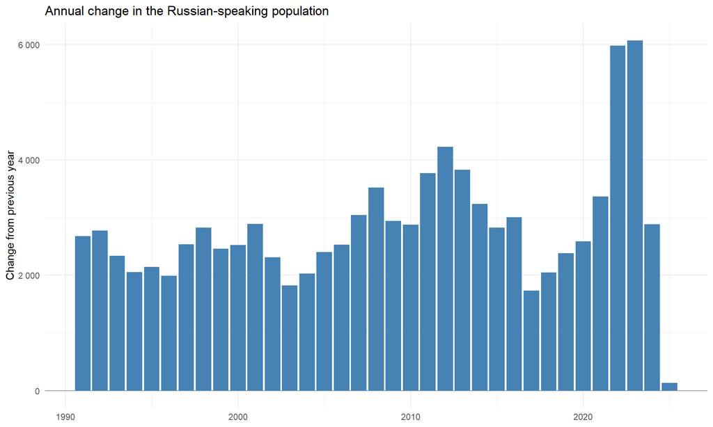

```r
ggplot(russian_annual, aes(Year, Change)) +
  geom_hline(yintercept = 0, colour = "grey60") +
  geom_col(fill = "steelblue") +
  scale_y_continuous(labels = label_number(big.mark = " ")) +
  labs(title = "Annual change in the Russian-speaking population",
       x = NULL, y = "Change from previous year") +
  theme_minimal()
```

## 2.2 Age profile over time

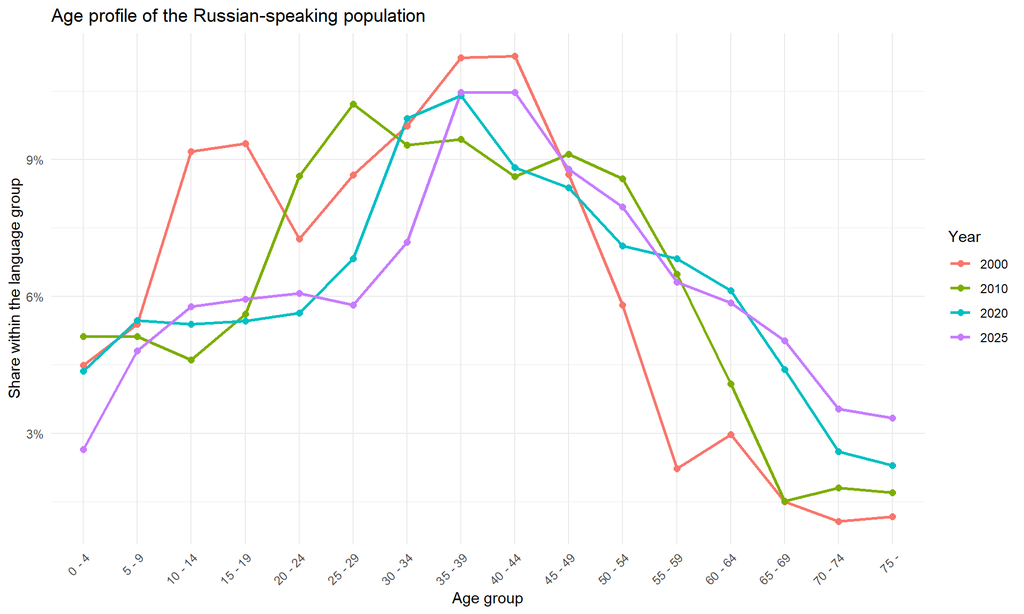

```r
russian_profile <- tulos_age %>%
  filter(Language == "Russian", Year %in% c(2000, 2010, 2020, 2025)) %>%
  group_by(Year) %>%
  mutate(Share = `Population 31 Dec` / sum(`Population 31 Dec`)) %>%
  ungroup()

ggplot(russian_profile, aes(Age, Share, colour = factor(Year), group = Year)) +
  geom_line(linewidth = 1) +
  geom_point(size = 2) +
  scale_y_continuous(labels = percent_format(accuracy = 1)) +
  labs(title = "Age profile of the Russian-speaking population",
       x = "Age group", y = "Share within the language group", colour = "Year") +
  theme_minimal() +
  theme(axis.text.x = element_text(angle = 45, hjust = 1))
```

# 3 Comparison of languages in 2025

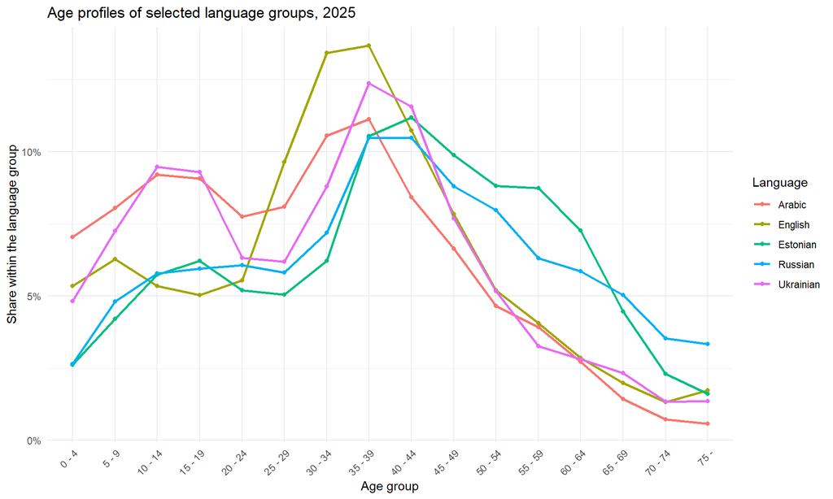

```r
selected_languages <- c("Russian", "Estonian", "Ukrainian", "Arabic", "English")

language_profiles <- tulos_age %>%
  filter(Language %in% selected_languages, Year == 2025) %>%
  group_by(Language) %>%
  mutate(Share = `Population 31 Dec` / sum(`Population 31 Dec`)) %>%
  ungroup()

ggplot(language_profiles, aes(Age, Share, colour = Language, group = Language)) +
  geom_line(linewidth = 1) +
  geom_point(size = 1.5) +
  scale_y_continuous(labels = percent_format(accuracy = 1)) +
  labs(title = "Age profiles of selected language groups, 2025",
       x = "Age group", y = "Share within the language group") +
  theme_minimal() +
  theme(axis.text.x = element_text(angle = 45, hjust = 1))
```

# 4 Five-year cohort comparison

A five-year comparison follows approximately the same cohort from one age group to the next. The open-ended `75 -` group is excluded because it contains survivors from several earlier cohorts.

```r
compare_cohorts <- function(data, language, start_year, end_year) {
  if (end_year - start_year != 5) {
    stop("The difference between start_year and end_year must be five years.")
  }

  start_data <- data %>%
    filter(Language == language, Year == start_year) %>%
    transmute(Age_start = as.character(Age), Population_start = `Population 31 Dec`)

  end_data <- data %>%
    filter(Language == language, Year == end_year) %>%
    transmute(Age_end = as.character(Age), Population_end = `Population 31 Dec`)

  tibble(
    Age_start = head(age_levels, -1),
    Age_end = tail(age_levels, -1)
  ) %>%
    filter(Age_end != "75 -") %>%
    left_join(start_data, by = "Age_start") %>%
    left_join(end_data, by = "Age_end") %>%
    mutate(
      Change = Population_end - Population_start,
      Change_percent = 100 * Change / Population_start
    )
}
```

## 4.1 Russian cohorts, 2020-2025

```r
russian_cohorts <- compare_cohorts(tulos_age, "Russian", 2020, 2025)

knitr::kable(
  russian_cohorts,
  digits = 1,
  format.args = list(big.mark = " "),
  caption = "Approximate Russian-language cohorts from 2020 to 2025"
)
```

Approximate Russian-language cohorts from 2020 to 2025

| Age_start | Age_end | Population_start | Population_end | Change | Change_percent |
| --- | --- | --- | --- | --- | --- |
| 0 - 4 | 5 - 9 | 3 672 | 4 929 | 1 257 | 34.2 |
| 5 - 9 | 10 - 14 | 4 602 | 5 931 | 1 329 | 28.9 |
| 10 - 14 | 15 - 19 | 4 541 | 6 099 | 1 558 | 34.3 |
| 15 - 19 | 20 - 24 | 4 596 | 6 223 | 1 627 | 35.4 |
| 20 - 24 | 25 - 29 | 4 740 | 5 967 | 1 227 | 25.9 |
| 25 - 29 | 30 - 34 | 5 752 | 7 374 | 1 622 | 28.2 |
| 30 - 34 | 35 - 39 | 8 331 | 10 745 | 2 414 | 29.0 |
| 35 - 39 | 40 - 44 | 8 755 | 10 749 | 1 994 | 22.8 |
| 40 - 44 | 45 - 49 | 7 434 | 9 024 | 1 590 | 21.4 |
| 45 - 49 | 50 - 54 | 7 052 | 8 175 | 1 123 | 15.9 |
| 50 - 54 | 55 - 59 | 5 982 | 6 473 | 491 | 8.2 |
| 55 - 59 | 60 - 64 | 5 752 | 6 009 | 257 | 4.5 |
| 60 - 64 | 65 - 69 | 5 156 | 5 161 | 5 | 0.1 |
| 65 - 69 | 70 - 74 | 3 704 | 3 622 | -82 | -2.2 |

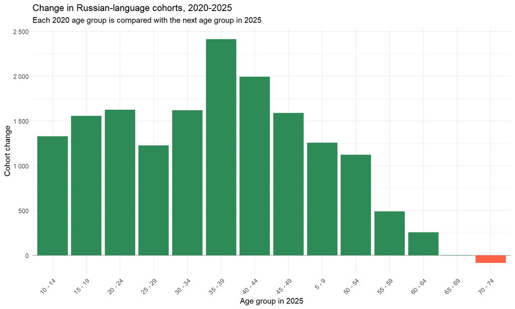

```r
ggplot(russian_cohorts, aes(Age_end, Change, fill = Change >= 0)) +
  geom_hline(yintercept = 0, colour = "grey60") +
  geom_col(show.legend = FALSE) +
  scale_fill_manual(values = c(`TRUE` = "seagreen", `FALSE` = "tomato")) +
  scale_y_continuous(labels = label_number(big.mark = " ")) +
  labs(title = "Change in Russian-language cohorts, 2020-2025",
       subtitle = "Each 2020 age group is compared with the next age group in 2025",
       x = "Age group in 2025", y = "Cohort change") +
  theme_minimal() +
  theme(axis.text.x = element_text(angle = 45, hjust = 1))
```

## 4.2 Rolling five-year comparisons

The single 2020-2025 comparison combines several different migration periods. The overlapping windows below show whether cohort growth strengthened or weakened in windows ending from 2020 to 2025.

```r
rolling_russian <- bind_rows(lapply(2020:2025, function(end_year) {
  compare_cohorts(
    tulos_age,
    language = "Russian",
    start_year = end_year - 5,
    end_year = end_year
  ) %>%
    mutate(
      Start_year = end_year - 5,
      End_year = end_year,
      Window = paste0(end_year - 5, "-", end_year)
    )
}))

rolling_russian <- rolling_russian %>%
  mutate(
    Window = factor(Window, levels = paste0(2015:2020, "-", 2020:2025)),
    Age_end = factor(Age_end, levels = age_levels[2:(length(age_levels) - 1)])
  )
```

### 4.2.1 Heat map of absolute cohort change

Each cell compares one age group with the same approximate birth cohort five years later. Positive values mean that additions to the registered Russian-language cohort exceeded removals during the five-year window.

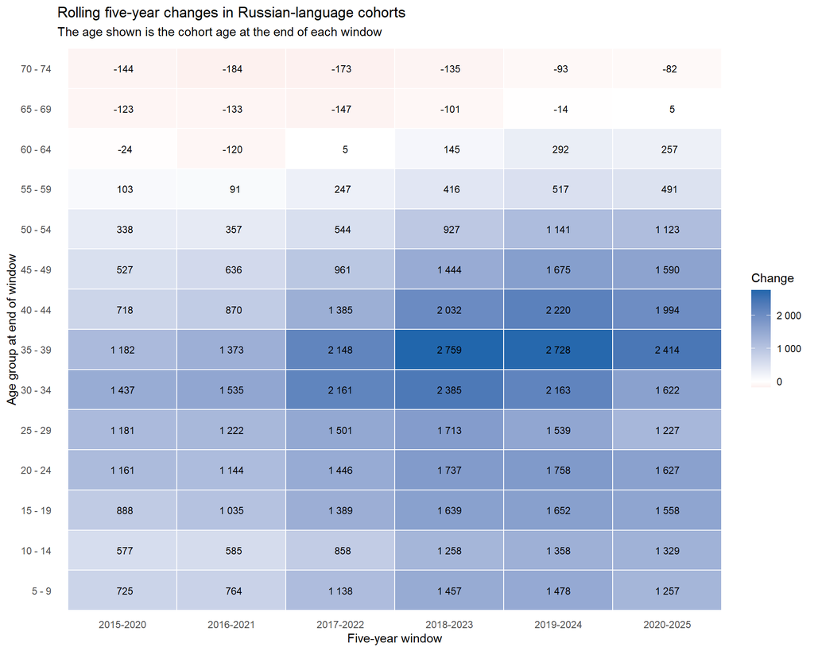

```r
ggplot(rolling_russian, aes(Window, Age_end, fill = Change)) +
  geom_tile(colour = "white", linewidth = 0.4) +
  geom_text(
    aes(label = format(round(Change), big.mark = " ", scientific = FALSE)),
    size = 3
  ) +
  scale_fill_gradient2(
    low = "#B2182B", mid = "white", high = "#2166AC",
    midpoint = 0,
    labels = label_number(big.mark = " ")
  ) +
  labs(
    title = "Rolling five-year changes in Russian-language cohorts",
    subtitle = "The age shown is the cohort age at the end of each window",
    x = "Five-year window", y = "Age group at end of window",
    fill = "Change"
  ) +
  theme_minimal() +
  theme(panel.grid = element_blank())
```

### 4.2.2 Sum across comparable cohorts

This summary excludes the new 0-4 group and the open-ended 75+ group. It is therefore a cohort indicator, not the total population change.

```r
rolling_summary <- rolling_russian %>%
  group_by(Start_year, End_year, Window) %>%
  summarise(
    Comparable_cohort_change = sum(Change),
    .groups = "drop"
  )

knitr::kable(
  rolling_summary,
  format.args = list(big.mark = " "),
  caption = "Sum of changes across comparable Russian-language cohorts"
)
```

Sum of changes across comparable Russian-language cohorts

| Start_year | End_year | Window | Comparable_cohort_change |
| --- | --- | --- | --- |
| 2 015 | 2 020 | 2015-2020 | 8 546 |
| 2 016 | 2 021 | 2016-2021 | 9 175 |
| 2 017 | 2 022 | 2017-2022 | 13 463 |
| 2 018 | 2 023 | 2018-2023 | 17 676 |
| 2 019 | 2 024 | 2019-2024 | 18 414 |
| 2 020 | 2 025 | 2020-2025 | 16 412 |

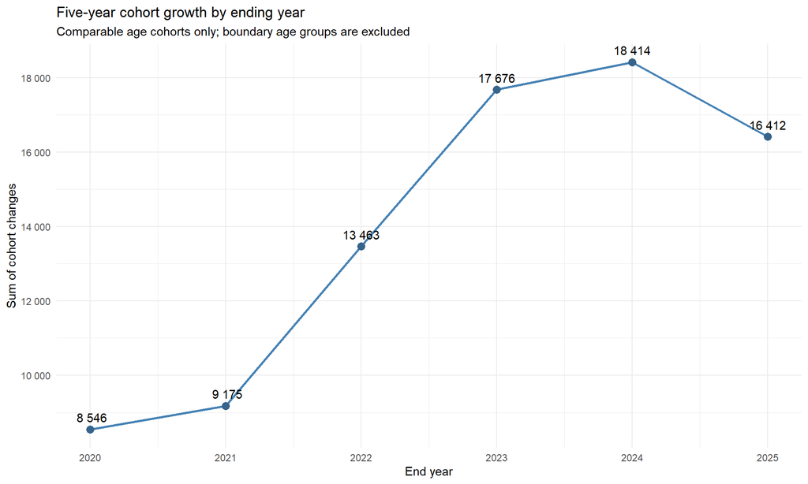

```r
ggplot(rolling_summary, aes(End_year, Comparable_cohort_change)) +
  geom_line(linewidth = 1, colour = "steelblue") +
  geom_point(size = 3, colour = "steelblue4") +
  geom_text(
    aes(label = format(Comparable_cohort_change, big.mark = " ",
                       scientific = FALSE)),
    vjust = -0.8
  ) +
  scale_x_continuous(breaks = rolling_summary$End_year) +
  scale_y_continuous(labels = label_number(big.mark = " ")) +
  labs(
    title = "Five-year cohort growth by ending year",
    subtitle = "Comparable age cohorts only; boundary age groups are excluded",
    x = "End year", y = "Sum of cohort changes"
  ) +
  theme_minimal()
```

# 5 Interpretation limits

The data describe population stocks on 31 December, not demographic flows. An increase in a cohort is consistent with net migration, but it can also include changes in registered language and statistical corrections. A decrease can include emigration and mortality. Exact causal decomposition requires migration, birth and death data in addition to `tulos_age.rds`.